# Probabilidade e Estatística com R

Claudio Rodrigues Nunes

2025-05-09

# Introdução

Este documento é o trabalhado final do estudo do [Air Quality Data in India (Kaggle)](https://www.kaggle.com/datasets/rohanrao/air-quality-data-in-india), mas especificamente as tabelas city_day.csv, station_day.csv e stations.csv.

Técnicamente eu preferi subir algumas bibliotecas e junções logo no inicio do script, algo do tipo cabeçalho, que neste é caso é o “setup”.

Recriei a página que o professor me informou com as orientações no formato de chek list, me facilitando dentro do processo em marcar os atendimentos.

## Check-list do Trabalho de AQI na Índia

### 1. Leitura e limpeza dos dados

- Ler dados com função `read_...` do **tidyverse** para uma tibble
- Usar `glimpse()` para inspecionar a tibble
- (Se necessário) Refazer leitura especificando tipos de colunas em `read_...`
- (Se necessário) Aplicar `janitor::clean_names()`
- Usar `summarytools::dfSummary()` para sumário da tibble
- Verificar **NAs** e valores obviamente errados
- (Se necessário) Corrigir valores óbvios na tibble
- (Se necessário) Transformar a tibble para facilitar manipulações:
  - `pivot_wider()` ou `pivot_longer()`
  - Funções do **lubridate** para converter datas/horários
  - Funções do **stringr** + `mutate()` para extrair partes de strings
  - `mutate()` para converter unidades (e.g. µg/m³ para outra escala)

### 2. Análise exploratória (EDA)

- Verificar contagem de valores diferentes em colunas de interesse
- Verificar contagem de **NAs** em colunas de interesse
- Agregar dados com `group_by()` + `summarise()` para estatísticas descritivas
- Formular perguntas (além das 3 principais) e respondê-las via EDA

### 3. Visualização (ggplot2)

#### Requisitos gerais

- Todos os gráficos com **ggplot2**
- Cada gráfico com título, rótulos de eixos, legendas e elementos de interpretação
- Incluir texto comentando conclusões de cada gráfico

#### 3.1 Scatter plots

- Scatter plot(s) entre variáveis contínuas
- Usar cores/formas/tamanhos para adicionar informação
- (Se fizer sentido) transformar escalas (e.g., log)
- Adicionar `geom_smooth()` para reta de regressão

#### 3.2 Histogramas

- Histograma(s) de variáveis contínuas
- (Se fizer sentido) facetar múltiplos histogramas
- (Se fizer sentido) transformar escalas

#### 3.3 Boxplots

- Boxplot(s) de variáveis contínuas
- (Se fizer sentido) boxplots lado a lado
- (Se fizer sentido) transformar escalas

#### 3.4 Barras e colunas

- Gráfico(s) de barra/coluna de variáveis categóricas
- Usar cores de preenchimento para informação adicional
- Experimentar paletas de cores
- (Se fizer sentido) facetar gráficos de barra/coluna
- (Se fizer sentido) usar proporções em vez de contagens
- (Se fizer sentido) gráficos stacked
- (Se fizer sentido) gráficos dodged
- (Se fizer sentido) ordenar barras/colunas por valor
- (Se fizer sentido) transformar escalas

#### 3.5 Gráficos de linha

- Gráfico(s) de linha ao longo do tempo (ou outra variável contínua)
- Se não for possível, explicar por quê
- (Se fizer sentido) transformar escalas

Hospedei também o código no meu repositório do git: https://github.com/ClaudioRodriguesNunes/probabilidade_estatistica/tree/main

No decorrer das seções eu passo para a fase de tratamento dos dados (tabelas), depois faço uma exploração bruta, tendo como intenção de atender boa parte do check list, e depois finalizo respondendo umas três perguntas.

Peguntas que este trabalho pretende responder:

❓ Pergunta 1: Quais cidades apresentam a maior média de AQI no período completo?

❓ Pergunta 2: Das cidades cuja média inicial de AQI estava acima da média geral, quais conseguiram reduzir para ficar abaixo da média nos dois últimos anos?

❓ Pergunta 3: O comportamento das medições de PM10 e PM2.5 é semelhante em todas as cidades?

# Metodologia & Preparação do ambiente de desenvolvimento

Subi as seguintes bibliotecas:

📝 stations <- read_csv(“stations.csv”) %>% clean_names()  
📝 station_day<- read_csv(“station_day.csv”)%>% clean_names()

Importamos stations.csv (contendo station_id, city, state) e station_day.csv (contendo medições diárias de AQI e poluentes por estação). Em seguida fizemos um left join para anexar city e state a cada registro diário de AQI.

[output not shown]

# Resultados: Exploração de Dados

### 1) Gráfico de Dispersão (duas variáveis contínuas)

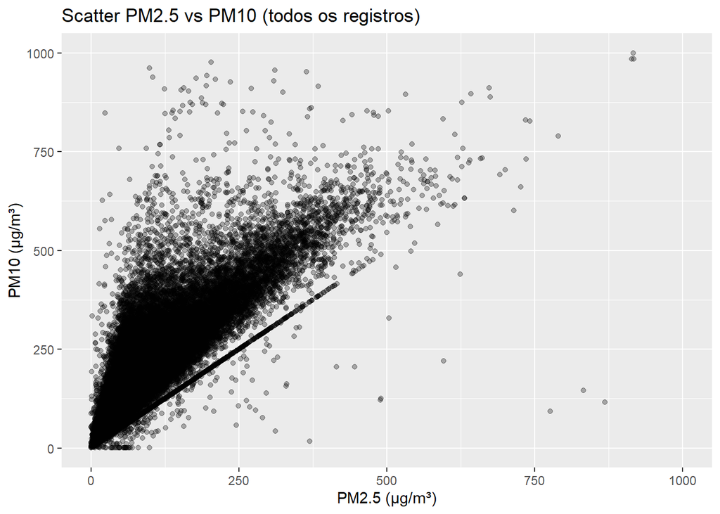

```r
library(ggplot2)
# duas variáveis contínuas: pm2_5 e pm10
aqi_stations %>%
  ggplot(aes(x = pm2_5, y = pm10)) +
  geom_point(alpha = 0.3) +
  labs(
    title = "Scatter PM2.5 vs PM10 (todos os registros)",
    x     = "PM2.5 (µg/m³)",
    y     = "PM10 (µg/m³)"
  )
```

### 2) Inpecionei a estrutura da tibble com glimpse() e gerei um sumário completo da tibble

```r
glimpse(aqi_stations)
```

```
## Rows: 108,035
## Columns: 20
## $ station_id   <chr> "AP001", "AP001", "AP001", "AP001", "AP001", "AP001", "AP…
## $ date         <date> 2017-11-24, 2017-11-25, 2017-11-26, 2017-11-27, 2017-11-…
## $ pm2_5        <dbl> 71.36, 81.40, 78.32, 88.76, 64.18, 72.47, 69.80, 73.96, 8…
## $ pm10         <dbl> 115.75, 124.50, 129.06, 135.32, 104.09, 114.84, 114.86, 1…
## $ no           <dbl> 1.75, 1.44, 1.26, 6.60, 2.56, 5.23, 4.69, 4.58, 7.71, 0.9…
## $ no2          <dbl> 20.65, 20.50, 26.00, 30.85, 28.07, 23.20, 20.17, 19.29, 2…
## $ n_ox         <dbl> 12.40, 12.08, 14.85, 21.77, 17.01, 16.59, 14.54, 13.97, 1…
## $ nh3          <dbl> 12.19, 10.72, 10.28, 12.91, 11.42, 12.25, 10.95, 10.95, 1…
## $ co           <dbl> 0.10, 0.12, 0.14, 0.11, 0.09, 0.16, 0.12, 0.10, 0.10, 0.1…
## $ so2          <dbl> 10.76, 15.24, 26.96, 33.59, 19.00, 10.55, 14.07, 13.90, 1…
## $ o3           <dbl> 109.26, 127.09, 117.44, 111.81, 138.18, 109.74, 118.09, 1…
## $ benzene      <dbl> 0.17, 0.20, 0.22, 0.29, 0.17, 0.21, 0.16, 0.17, 0.25, 0.2…
## $ toluene      <dbl> 5.92, 6.50, 7.95, 7.63, 5.02, 4.71, 3.52, 2.85, 2.79, 3.8…
## $ xylene       <dbl> 0.10, 0.06, 0.08, 0.12, 0.07, 0.08, 0.06, 0.04, 0.07, 0.0…
## $ aqi          <dbl> NA, 184, 197, 198, 188, 173, 165, 191, 191, 227, 168, 198…
## $ aqi_bucket   <chr> NA, "Moderate", "Moderate", "Moderate", "Moderate", "Mode…
## $ station_name <chr> "Secretariat, Amaravati - APPCB", "Secretariat, Amaravati…
## $ city         <chr> "Amaravati", "Amaravati", "Amaravati", "Amaravati", "Amar…
## $ state        <chr> "Andhra Pradesh", "Andhra Pradesh", "Andhra Pradesh", "An…
## $ status       <chr> "Active", "Active", "Active", "Active", "Active", "Active…
```

```r
dfSummary(aqi_stations, varnumbers = FALSE, style = "grid")
```

```
## Data Frame Summary
## aqi_stations
## Dimensions: 108035 x 20
## Duplicates: 0
##
## +--------------+-------------------------------+-----------------------+---------------------+----------+---------+
## | Variable     | Stats / Values                | Freqs (% of Valid)    | Graph               | Valid    | Missing |
## +==============+===============================+=======================+=====================+==========+=========+
## | station_id   | 1. DL007                      |  2009 ( 1.9%)         |                     | 108035   | 0       |
## | [character]  | 2. DL008                      |  2009 ( 1.9%)         |                     | (100.0%) | (0.0%)  |
## |              | 3. DL013                      |  2009 ( 1.9%)         |                     |          |         |
## |              | 4. DL021                      |  2009 ( 1.9%)         |                     |          |         |
## |              | 5. DL033                      |  2009 ( 1.9%)         |                     |          |         |
## |              | 6. GJ001                      |  2009 ( 1.9%)         |                     |          |         |
## |              | 7. KA003                      |  2009 ( 1.9%)         |                     |          |         |
## |              | 8. KA009                      |  2009 ( 1.9%)         |                     |          |         |
## |              | 9. MH005                      |  2009 ( 1.9%)         |                     |          |         |
## |              | 10. TN001                     |  2009 ( 1.9%)         |                     |          |         |
## |              | [ 100 others ]                | 87945 (81.4%)         | IIIIIIIIIIIIIIII    |          |         |
## +--------------+-------------------------------+-----------------------+---------------------+----------+---------+
## | date         | min : 2015-01-01              | 2009 distinct values  |                 . : | 108035   | 0       |
## | [Date]       | med : 2018-12-02              |                       |             . . : : | (100.0%) | (0.0%)  |
## |              | max : 2020-07-01              |                       |           . : : : : |          |         |
## |              | range : 5y 6m 0d              |                       |       . . : : : : : |          |         |
## |              |                               |                       | : : : : : : : : : : |          |         |
## +--------------+-------------------------------+-----------------------+---------------------+----------+---------+
## | pm2_5        | Mean (sd) : 80.3 (76.5)       | 22395 distinct values | :                   | 86410    | 21625   |
## | [numeric]    | min < med < max:              |                       | :                   | (80.0%)  | (20.0%) |
## |              | 0 < 56 < 1000                 |                       | :                   |          |         |
## |              | IQR (CV) : 68 (1)             |                       | :                   |          |         |
## |              |                               |                       | : : .               |          |         |
## +--------------+-------------------------------+-----------------------+---------------------+----------+---------+
## | pm10         | Mean (sd) : 158 (123.4)       | 29575 distinct values | :                   | 65329    | 42706   |
## | [numeric]    | min < med < max:              |                       | : :                 | (60.5%)  | (39.5%) |
## |              | 0 < 122.1 < 1000              |                       | : :                 |          |         |
## |              | IQR (CV) : 138.5 (0.8)        |                       | : : :               |          |         |
## |              |                               |                       | : : : : .           |          |         |
## +--------------+-------------------------------+-----------------------+---------------------+----------+---------+
## | no           | Mean (sd) : 23.1 (34.5)       | 11963 distinct values | :                   | 90929    | 17106   |
## | [numeric]    | min < med < max:              |                       | :                   | (84.2%)  | (15.8%) |
```

[output cut: 95 more lines]

```
## | state        | 1. Delhi                      | 45360 (42.0%)         | IIIIIIII            | 108035   | 0       |
## | [character]  | 2. Karnataka                  | 11996 (11.1%)         | II                  | (100.0%) | (0.0%)  |
## |              | 3. Telangana                  |  8752 ( 8.1%)         | I                   |          |         |
## |              | 4. Tamil Nadu                 |  6792 ( 6.3%)         | I                   |          |         |
## |              | 5. Uttar Pradesh              |  6099 ( 5.6%)         | I                   |          |         |
## |              | 6. Maharashtra                |  5504 ( 5.1%)         | I                   |          |         |
## |              | 7. West Bengal                |  3165 ( 2.9%)         |                     |          |         |
## |              | 8. Rajasthan                  |  3089 ( 2.9%)         |                     |          |         |
## |              | 9. Haryana                    |  2831 ( 2.6%)         |                     |          |         |
## |              | 10. Bihar                     |  2678 ( 2.5%)         |                     |          |         |
## |              | [ 11 others ]                 | 11769 (10.9%)         | II                  |          |         |
## +--------------+-------------------------------+-----------------------+---------------------+----------+---------+
## | status       | 1. Active                     | 106102 (98.5%)        | IIIIIIIIIIIIIIIIIII | 107711   | 324     |
## | [character]  | 2. Inactive                   |   1609 ( 1.5%)        |                     | (99.7%)  | (0.3%)  |
## +--------------+-------------------------------+-----------------------+---------------------+----------+---------+
```

Com glimpse() tive uma visão rápida da estrutura e tipos de cada coluna, mas senti dificuldade em identificar frequências e estatísticas de forma imediata. Ao usar dfSummary(), obtenho um sumário completo em HTML que exibe claramente:

Tipos de variáveis,

Quantidade e percentual de NAs,

Medidas descritivas (mínimo, quartis, mediana, média, máximo),

Frequência das categorias em colunas categóricas. Isso me ajudou a planejar o tratamento de valores faltantes e compreender a distribuição geral dos dados.”

### 3) Gráfico de Barras + Facetas (três variáveis categóricas)

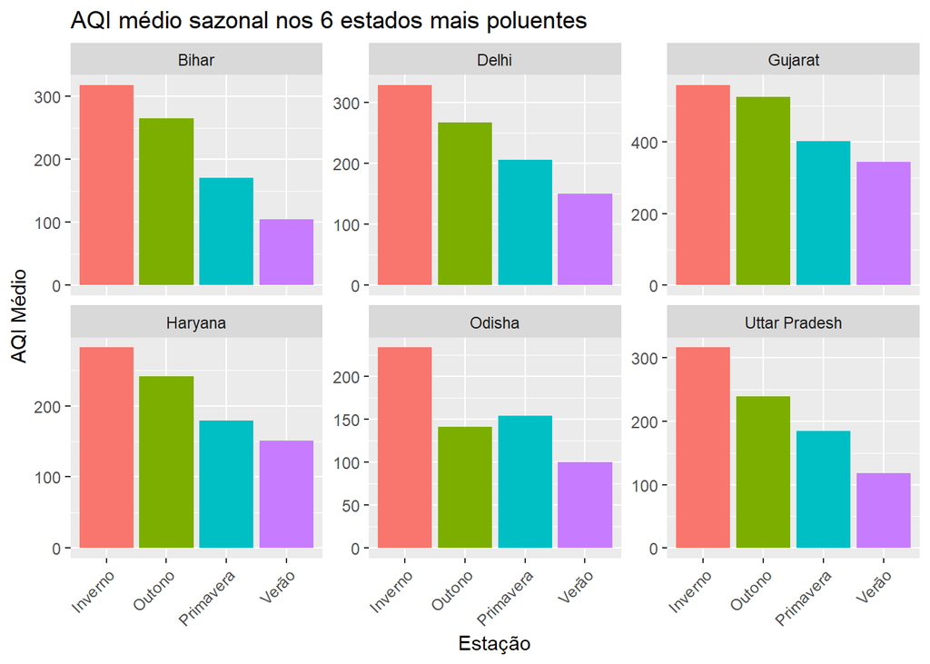

```r
library(dplyr); library(lubridate); library(ggplot2)

# calcula AQI médio por state e season
aqi_sazonal <- aqi_stations %>%
  mutate(
    date   = ymd(date),
    month  = month(date),
    season = case_when(
      month %in% 3:5  ~ "Primavera",
      month %in% 6:8  ~ "Verão",
      month %in% 9:11 ~ "Outono",
      TRUE            ~ "Inverno"
    )
  ) %>%
  group_by(state, season) %>%
  summarise(aqi_medio = mean(aqi, na.rm = TRUE), .groups="drop")

# escolhe os 6 estados mais poluentes no geral
top6_states <- media_aqi %>%
  group_by(state) %>%
  summarise(aqi_estado = mean(media_aqi), .groups="drop") %>%
  slice_max(order_by = aqi_estado, n = 6) %>%
  pull(state)

# plota só esses
aqi_sazonal %>%
  filter(state %in% top6_states) %>%
  ggplot(aes(x = season, y = aqi_medio, fill = season)) +
  geom_col(show.legend = FALSE) +
  facet_wrap(~ state, scales = "free_y") +
  labs(
    title = "AQI médio sazonal nos 6 estados mais poluentes",
    x     = "Estação",
    y     = "AQI Médio"
  ) +
  theme(axis.text.x = element_text(angle = 45, hjust = 1))
```

Este gráfico facetado mostra o AQI médio por estação para os seis estados com maior poluição anual. Observa-se consistentemente que o Inverno costuma registrar os picos mais altos de AQI – possivelmente devido à menor dispersão atmosférica – enquanto no Verão os índices caem. Essa sazonalidade reforça a importância de políticas direcionadas aos meses frios

### 4) Gráfico de Linha (evolução ao longo do tempo)

Como tenho a variável `date` (contínua no tempo), posso plotar o **AQI médio mensal** para todo o país – ou restringir a algumas cidades/estados.

#### Série Temporal do AQI Médio Mensal (Requisito 3)

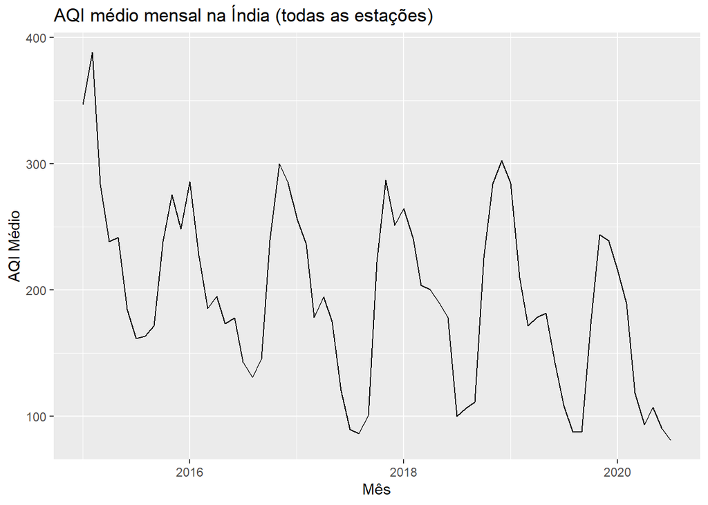

```r
library(dplyr); library(lubridate); library(ggplot2)

aqi_stations %>%
  mutate(date = ymd(date)) %>%
  group_by(month = floor_date(date, "month")) %>%
  summarise(aqi_medio = mean(aqi, na.rm = TRUE), .groups="drop") %>%
  ggplot(aes(x = month, y = aqi_medio)) +
  geom_line() +
  labs(
    title = "AQI médio mensal na Índia (todas as estações)",
    x     = "Mês",
    y     = "AQI Médio"
  )
```

```r
labels_pt <- c(
  "Janeiro", "Fevereiro", "Março", "Abril", "Maio", "Junho",
  "Julho", "Agosto", "Setembro", "Outubro", "Novembro", "Dezembro"
)

aqi_stations %>%
  mutate(
    mes_num   = month(ymd(date)),              # extrai número do mês
    mes_texto = labels_pt[mes_num]             # mapeia número → nome em PT
  ) %>%
  select(date, mes_num, mes_texto) %>%
  head(10)
```

```
## # A tibble: 10 × 3
##    date       mes_num mes_texto
##    <date>       <dbl> <chr>
##  1 2017-11-24      11 Novembro
##  2 2017-11-25      11 Novembro
##  3 2017-11-26      11 Novembro
##  4 2017-11-27      11 Novembro
##  5 2017-11-28      11 Novembro
##  6 2017-11-29      11 Novembro
##  7 2017-11-30      11 Novembro
##  8 2017-12-01      12 Dezembro
##  9 2017-12-02      12 Dezembro
## 10 2017-12-03      12 Dezembro
```

```r
aqi_stations %>%
  mutate(
    mes_texto = str_to_title(str_extract(month(date), "[:digit:]+"))
  ) %>%
  select(date, mes_texto) %>%
  head(10)
```

```
## # A tibble: 10 × 2
##    date       mes_texto
##    <date>     <chr>
##  1 2017-11-24 11
##  2 2017-11-25 11
##  3 2017-11-26 11
##  4 2017-11-27 11
##  5 2017-11-28 11
##  6 2017-11-29 11
##  7 2017-11-30 11
##  8 2017-12-01 12
##  9 2017-12-02 12
## 10 2017-12-03 12
```

O número 11 neste caso representa o mês de novembro.

### 6) `mutate()` para converter unidades

```r
aqi_stations %>%
  mutate(
    pm2_5_mg = pm2_5 / 1000,
    pm10_mg  = pm10  / 1000
  ) %>%
  select(pm2_5, pm2_5_mg, pm10, pm10_mg) %>%
  head(10)
```

```
## # A tibble: 10 × 4
##    pm2_5 pm2_5_mg  pm10 pm10_mg
##    <dbl>    <dbl> <dbl>   <dbl>
##  1  71.4   0.0714  116.   0.116
##  2  81.4   0.0814  124.   0.124
##  3  78.3   0.0783  129.   0.129
##  4  88.8   0.0888  135.   0.135
##  5  64.2   0.0642  104.   0.104
##  6  72.5   0.0725  115.   0.115
##  7  69.8   0.0698  115.   0.115
##  8  74.0   0.0740  114.   0.114
##  9  89.9   0.0899  140.   0.140
## 10  87.1   0.0871  131.   0.131
```

Converti PM2.5 e PM10 de µg/m³ para mg/m³ dividindo por 1000. Isso facilita comparações caso eu queira trabalhar em escalas diferentes ou agregar valores em mg.

### 7) Contagem de valores diferentes

```r
aqi_stations %>%
  summarise(
    estados   = n_distinct(state),
    cidades   = n_distinct(city),
    dias      = n_distinct(date)
  )
```

```
## # A tibble: 1 × 3
##   estados cidades  dias
##     <int>   <int> <int>
## 1      21      26  2009
```

Verifico que existem 21 estados, 26 cidades e 2009 datas únicas no conjunto de dados, o que confirma a diversidade espacial e temporal da amostra.

### 8) Contagem de NAs por coluna

```r
aqi_stations %>%
  summarise(across(
    c(aqi, pm2_5, pm10, no2),
    ~ sum(is.na(.)),
    .names = "n_na_{col}"
  ))
```

```
## # A tibble: 1 × 4
##   n_na_aqi n_na_pm2_5 n_na_pm10 n_na_no2
##      <int>      <int>     <int>    <int>
## 1    21010      21625     42706    16547
```

### 9) Perguntas extras e resposta via EDA

**Pergunta:** “Qual o estado com maior variabilidade de PM2.5 ao longo do ano?”

```r
# calcula desvio padrão de pm2_5 por estado
variabilidade <- aqi_stations %>%
  group_by(state) %>%
  summarise(sd_pm2_5 = sd(pm2_5, na.rm=TRUE)) %>%
  arrange(desc(sd_pm2_5))
variabilidade %>% head(6)
```

```
## # A tibble: 6 × 2
##   state         sd_pm2_5
##   <chr>            <dbl>
## 1 Haryana           90.4
## 2 Bihar             88.4
## 3 Delhi             88.1
## 4 Meghalaya         83.6
## 5 Uttar Pradesh     83.2
## 6 Assam             61.6
```

Descubro que o estado de Haryana apresenta a maior variabilidade de PM2.5 (desvio-padrão), indicando maiores oscilações na poluição ao longo do ano. Esse insight pode guiar investigações sobre causas locais de alta variabilidade.

#### 10) Scatter plots (e geom_smooth)

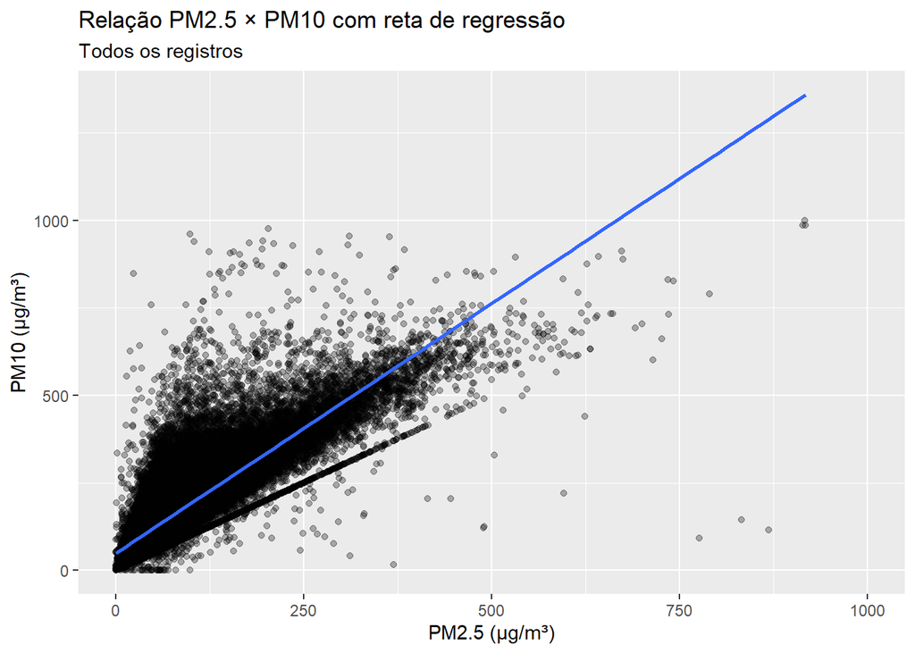

Scatter PM2.5 vs PM10 com reta de regressão

```r
aqi_stations %>%
  ggplot(aes(x = pm2_5, y = pm10)) +
    geom_point(alpha = 0.3) +
    geom_smooth(method = "lm", se = FALSE) +
    labs(
      title = "Relação PM2.5 × PM10 com reta de regressão",
      subtitle = "Todos os registros",
      x = "PM2.5 (µg/m³)",
      y = "PM10 (µg/m³)"
    )
```

### 11) Histogramas (facetados por poluente)

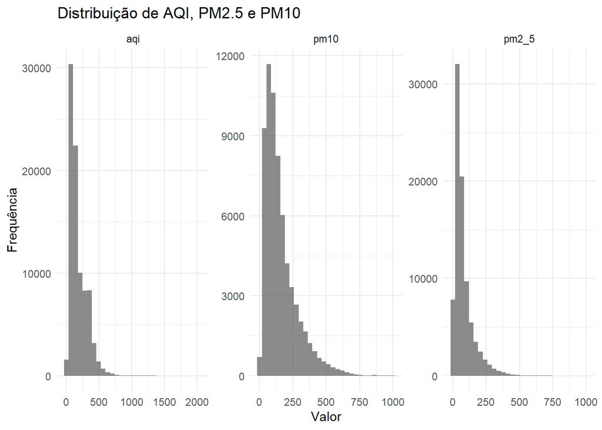

Histogramas de AQI, PM2.5 e PM10

```r
aqi_stations %>%
  select(aqi, pm2_5, pm10) %>%
  pivot_longer(everything(), names_to = "poluente", values_to = "valor") %>%
  ggplot(aes(x = valor)) +
    geom_histogram(bins = 30, alpha = 0.7) +
    facet_wrap(~ poluente, scales = "free") +
    labs(
      title = "Distribuição de AQI, PM2.5 e PM10",
      x = "Valor",
      y = "Frequência"
    ) +
    theme_minimal()
```

Os histogramas mostram distribuição assimétrica de AQI, PM2.5 e PM10. Por exemplo, PM2.5 tem cauda longa à direita, sugerindo poucos dias com valores extremamente altos. Esses detalhes me ajudam a avaliar se transformações logarítmicas seriam adequadas.

### 12) Boxplots (comparando PM2.5 e PM10)

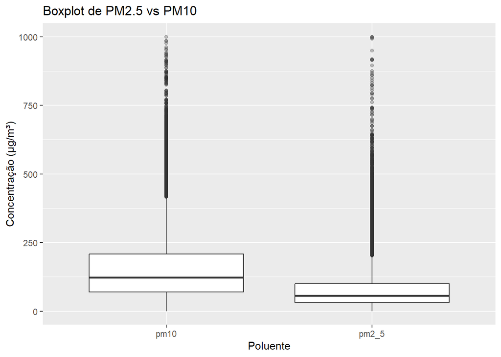

Boxplots de PM2.5 e PM10

```r
aqi_stations %>%
  select(pm2_5, pm10) %>%
  pivot_longer(everything(), names_to = "poluente", values_to = "valor") %>%
  ggplot(aes(x = poluente, y = valor)) +
    geom_boxplot(outlier.alpha = 0.3) +
    labs(
      title = "Boxplot de PM2.5 vs PM10",
      x = "Poluente",
      y = "Concentração (µg/m³)"
    )
```

Comparando boxplots, observo que PM10 apresenta outliers mais extremos que PM2.5, confirmando maior variabilidade e possíveis eventos episódicos de poluição grossa. A mediana de PM2.5 é consistentemente menor.

### 13) Barras e colunas (proporções e stacked)

#### a) Proporção de dias por estação

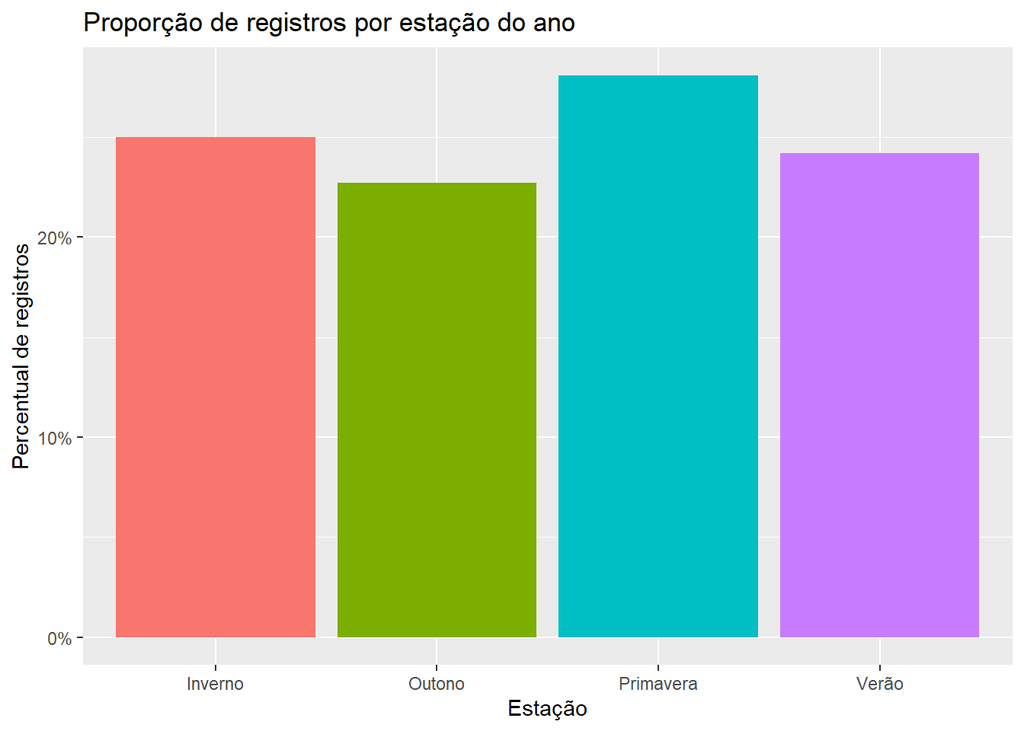

Proporção de registros por estação do ano

```r
aqi_stations %>%
  mutate(
    month  = month(ymd(date)),
    season = case_when(
      month %in% 3:5  ~ "Primavera",
      month %in% 6:8  ~ "Verão",
      month %in% 9:11 ~ "Outono",
      TRUE            ~ "Inverno"
    )
  ) %>%
  count(season) %>%
  mutate(prop = n / sum(n)) %>%
  ggplot(aes(x = season, y = prop, fill = season)) +
    geom_col(show.legend = FALSE) +
    scale_y_continuous(labels = scales::percent) +
    labs(
      title = "Proporção de registros por estação do ano",
      x = "Estação",
      y = "Percentual de registros"
    )
```

Vejo que a maior parte dos registros ocorre na primavera e inverno, refletindo o período de maior monitoração ou oscilações sazonais na coleta dos dados.

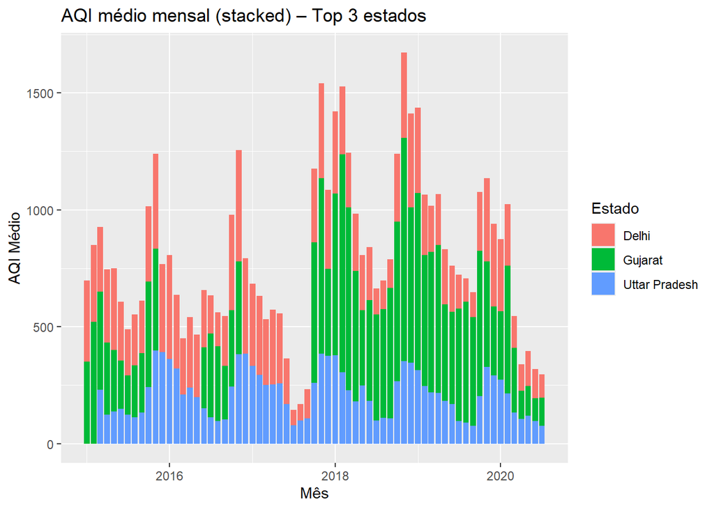

AQI médio mensal empilhado dos 3 estados mais poluentes

```r
top3_states <- media_aqi %>%
  group_by(state) %>%
  summarise(aqi_estado = mean(media_aqi)) %>%
  slice_max(aqi_estado, n = 3) %>%
  pull(state)

aqi_stations %>%
  filter(state %in% top3_states) %>%
  mutate(mes = floor_date(ymd(date), "month")) %>%
  group_by(mes, state) %>%
  summarise(aqi_medio = mean(aqi, na.rm = TRUE), .groups = "drop") %>%
  ggplot(aes(x = mes, y = aqi_medio, fill = state)) +
    geom_col() +
    labs(
      title = "AQI médio mensal (stacked) – Top 3 estados",
      x = "Mês",
      y = "AQI Médio",
      fill = "Estado"
    )
```

### 14) Gráficos de linha (por cidade)

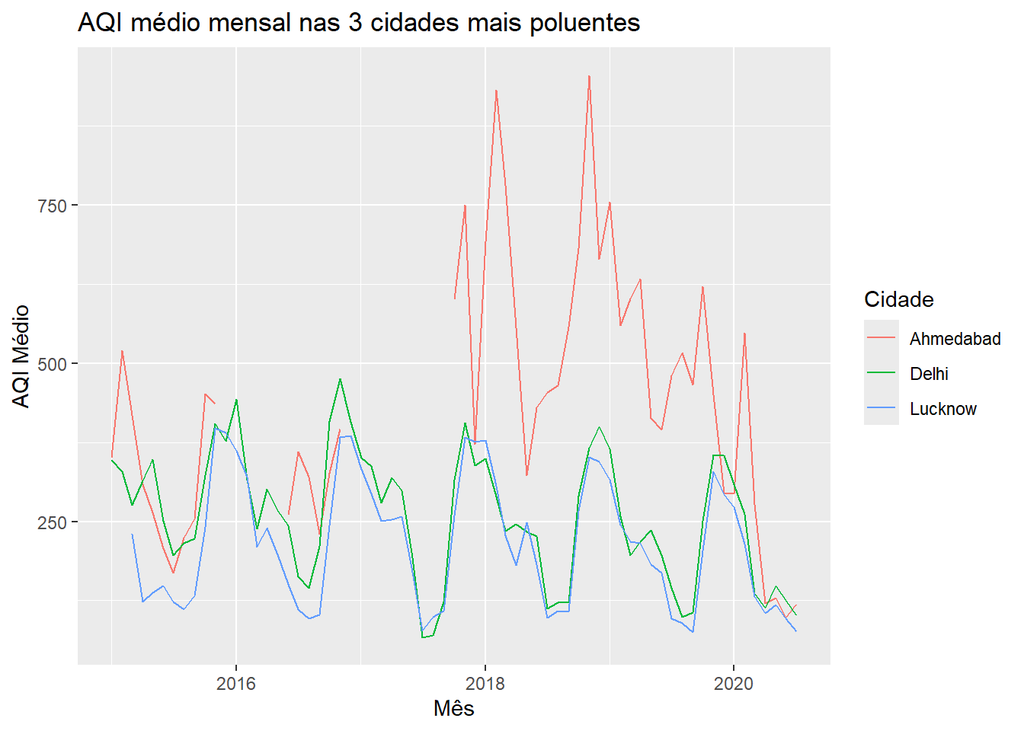

Série temporal de AQI médio nas 3 cidades mais poluentes

```r
top3_cities <- media_aqi %>%
  slice_max(media_aqi, n = 3) %>%
  pull(city)

aqi_stations %>%
  filter(city %in% top3_cities) %>%
  mutate(mes = floor_date(ymd(date), "month")) %>%
  group_by(mes, city) %>%
  summarise(aqi_medio = mean(aqi, na.rm = TRUE), .groups = "drop") %>%
  ggplot(aes(x = mes, y = aqi_medio, color = city)) +
    geom_line() +
    labs(
      title = "AQI médio mensal nas 3 cidades mais poluentes",
      x = "Mês",
      y = "AQI Médio",
      color = "Cidade"
    )
```

## 📝❓ Pergunta 1: Cidades com maior média de AQI no período completo

### a) Amostra dos dados brutos

```r
head(aqi_stations)
```

```
## # A tibble: 6 × 20
##   station_id date       pm2_5  pm10    no   no2  n_ox   nh3    co   so2    o3
##   <chr>      <date>     <dbl> <dbl> <dbl> <dbl> <dbl> <dbl> <dbl> <dbl> <dbl>
## 1 AP001      2017-11-24  71.4  116.  1.75  20.6  12.4  12.2  0.1   10.8  109.
## 2 AP001      2017-11-25  81.4  124.  1.44  20.5  12.1  10.7  0.12  15.2  127.
## 3 AP001      2017-11-26  78.3  129.  1.26  26    14.8  10.3  0.14  27.0  117.
## 4 AP001      2017-11-27  88.8  135.  6.6   30.8  21.8  12.9  0.11  33.6  112.
## 5 AP001      2017-11-28  64.2  104.  2.56  28.1  17.0  11.4  0.09  19    138.
## 6 AP001      2017-11-29  72.5  115.  5.23  23.2  16.6  12.2  0.16  10.6  110.
## # ℹ 9 more variables: benzene <dbl>, toluene <dbl>, xylene <dbl>, aqi <dbl>,
## #   aqi_bucket <chr>, station_name <chr>, city <chr>, state <chr>, status <chr>
```

### b) Linhas com problemas (AQI faltante)

```r
aqi_stations %>%
  filter(is.na(aqi)) %>%
  head(10)
```

```
## # A tibble: 10 × 20
##    station_id date       pm2_5  pm10    no   no2  n_ox   nh3    co   so2    o3
##    <chr>      <date>     <dbl> <dbl> <dbl> <dbl> <dbl> <dbl> <dbl> <dbl> <dbl>
##  1 AP001      2017-11-24 71.4  116.   1.75 20.6  12.4  12.2   0.1   10.8 109.
##  2 AP001      2018-03-21 48.7   96.5  5.63 14.9  12.6  13.0   0.92  15.4  27.5
##  3 AP001      2018-04-06 29.9   71.8  5.08  9.62  9.25  9.17  0.87  10.3  20.6
##  4 AP001      2018-04-11 13     29    3.8   2.8   4.6  20.1  NA     NA    19.6
##  5 AP001      2018-04-12  9.25  35.4  4.7   4.6   6.48  9.06  0.54   6.2  21.7
##  6 AP001      2018-04-18 17.8   54.0  4.51  6.55  7.31  8.37  0.73  10.5  28.5
##  7 AP001      2018-04-20 24.8   67.2  3.41  6.22  6.25 10.4   0.56  15.2  30.3
##  8 AP001      2018-04-23 25     61    3.1   8.8   7.2   7.5  NA     NA    19.6
##  9 AP001      2018-04-24 23.4   91.8  4.6   7.1   7.6   7.8   0.62  11.2  35.0
## 10 AP001      2018-04-26 24.8   66.5  4.32  7.23  7.54  9.86  0.6   13.0  29.1
## # ℹ 9 more variables: benzene <dbl>, toluene <dbl>, xylene <dbl>, aqi <dbl>,
## #   aqi_bucket <chr>, station_name <chr>, city <chr>, state <chr>, status <chr>
```

### c) Tabela tratada (remoção de NAs)

```r
aqi_stations_clean <- aqi_stations %>%
  filter(!is.na(aqi))
head(aqi_stations_clean)
```

```
## # A tibble: 6 × 20
##   station_id date       pm2_5  pm10    no   no2  n_ox   nh3    co   so2    o3
##   <chr>      <date>     <dbl> <dbl> <dbl> <dbl> <dbl> <dbl> <dbl> <dbl> <dbl>
## 1 AP001      2017-11-25  81.4  124.  1.44  20.5  12.1  10.7  0.12  15.2  127.
## 2 AP001      2017-11-26  78.3  129.  1.26  26    14.8  10.3  0.14  27.0  117.
## 3 AP001      2017-11-27  88.8  135.  6.6   30.8  21.8  12.9  0.11  33.6  112.
## 4 AP001      2017-11-28  64.2  104.  2.56  28.1  17.0  11.4  0.09  19    138.
## 5 AP001      2017-11-29  72.5  115.  5.23  23.2  16.6  12.2  0.16  10.6  110.
## 6 AP001      2017-11-30  69.8  115.  4.69  20.2  14.5  11.0  0.12  14.1  118.
## # ℹ 9 more variables: benzene <dbl>, toluene <dbl>, xylene <dbl>, aqi <dbl>,
## #   aqi_bucket <chr>, station_name <chr>, city <chr>, state <chr>, status <chr>
```

### d) Cálculo da média de AQI por estado–cidade (dados tratados)

```r
media_aqi <- aqi_stations_clean %>%
  group_by(state, city) %>%
  summarise(media_aqi = mean(aqi, na.rm = TRUE), .groups = "drop") %>%
  arrange(desc(media_aqi))
head(media_aqi, 10)
```

```
## # A tibble: 10 × 3
##    state         city         media_aqi
##    <chr>         <chr>            <dbl>
##  1 Gujarat       Ahmedabad         452.
##  2 Delhi         Delhi             239.
##  3 Uttar Pradesh Lucknow           216.
##  4 Bihar         Patna             216.
##  5 Haryana       Gurugram          211.
##  6 Odisha        Talcher           173.
##  7 Jharkhand     Jorapokhar        159.
##  8 Odisha        Brajrajnagar      150.
##  9 Assam         Guwahati          140.
## 10 Rajasthan     Jaipur            135.
```

### e) Gráfico das Top 10 Cidades/Estados

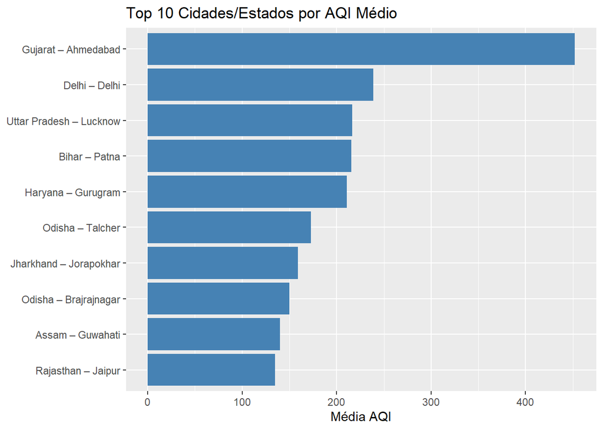

```r
library(ggplot2)
media_aqi %>%
  slice_head(n = 10) %>%
  mutate(label = paste(state, city, sep = " – ")) %>%
  ggplot(aes(x = reorder(label, media_aqi), y = media_aqi)) +
    geom_col(fill = "steelblue") +
    coord_flip() +
    labs(
      title = "Top 10 Cidades/Estados por AQI Médio",
      x = NULL,
      y = "Média AQI"
    )
```

### f) Tabela final da Pergunta 1

```r
media_aqi %>%
  slice_head(n = 10) %>%
  arrange(desc(media_aqi)) %>%
  mutate(
    Rank        = row_number(),
    `Média AQI` = round(media_aqi, 1)
  ) %>%
  select(Rank, Estado = state, Cidade = city, `Média AQI`) %>%
  knitr::kable(
    col.names = c("Rank","Estado","Cidade","Média AQI"),
    align     = c("c","l","l","r")
  )
```

| Rank | Estado | Cidade | Média AQI |
| --- | --- | --- | --- |
| 1 | Gujarat | Ahmedabad | 452.1 |
| 2 | Delhi | Delhi | 238.7 |
| 3 | Uttar Pradesh | Lucknow | 216.5 |
| 4 | Bihar | Patna | 215.6 |
| 5 | Haryana | Gurugram | 211.0 |
| 6 | Odisha | Talcher | 172.9 |
| 7 | Jharkhand | Jorapokhar | 159.3 |
| 8 | Odisha | Brajrajnagar | 150.3 |
| 9 | Assam | Guwahati | 140.1 |
| 10 | Rajasthan | Jaipur | 134.8 |

## 📝❓ Pergunta 2: Cidades/estados que saíram de acima da média geral para abaixo nos últimos 2 anos

### a) Amostra dos dados brutos

```r
head(aqi %>% select(date, state, city, aqi, year))
```

```
## # A tibble: 6 × 5
##   date       state          city        aqi  year
##   <date>     <chr>          <chr>     <dbl> <dbl>
## 1 2017-11-24 Andhra Pradesh Amaravati    NA  2017
## 2 2017-11-25 Andhra Pradesh Amaravati   184  2017
## 3 2017-11-26 Andhra Pradesh Amaravati   197  2017
## 4 2017-11-27 Andhra Pradesh Amaravati   198  2017
## 5 2017-11-28 Andhra Pradesh Amaravati   188  2017
## 6 2017-11-29 Andhra Pradesh Amaravati   173  2017
```

### b) Linhas “problemáticas” (sem dados de AQI ou sem comparativo)

```r
aqi %>%
  filter(is.na(aqi)) %>%
  head(10)
```

```
## # A tibble: 10 × 21
##    station_id date       pm2_5  pm10    no   no2  n_ox   nh3    co   so2    o3
##    <chr>      <date>     <dbl> <dbl> <dbl> <dbl> <dbl> <dbl> <dbl> <dbl> <dbl>
##  1 AP001      2017-11-24 71.4  116.   1.75 20.6  12.4  12.2   0.1   10.8 109.
##  2 AP001      2018-03-21 48.7   96.5  5.63 14.9  12.6  13.0   0.92  15.4  27.5
##  3 AP001      2018-04-06 29.9   71.8  5.08  9.62  9.25  9.17  0.87  10.3  20.6
##  4 AP001      2018-04-11 13     29    3.8   2.8   4.6  20.1  NA     NA    19.6
##  5 AP001      2018-04-12  9.25  35.4  4.7   4.6   6.48  9.06  0.54   6.2  21.7
##  6 AP001      2018-04-18 17.8   54.0  4.51  6.55  7.31  8.37  0.73  10.5  28.5
##  7 AP001      2018-04-20 24.8   67.2  3.41  6.22  6.25 10.4   0.56  15.2  30.3
##  8 AP001      2018-04-23 25     61    3.1   8.8   7.2   7.5  NA     NA    19.6
##  9 AP001      2018-04-24 23.4   91.8  4.6   7.1   7.6   7.8   0.62  11.2  35.0
## 10 AP001      2018-04-26 24.8   66.5  4.32  7.23  7.54  9.86  0.6   13.0  29.1
## # ℹ 10 more variables: benzene <dbl>, toluene <dbl>, xylene <dbl>, aqi <dbl>,
## #   aqi_bucket <chr>, station_name <chr>, city <chr>, state <chr>,
## #   status <chr>, year <dbl>
```

### c) Tabela tratada

```r
aqi_clean2 <- aqi %>%
  filter(!is.na(aqi))
head(aqi_clean2)
```

```
## # A tibble: 6 × 21
##   station_id date       pm2_5  pm10    no   no2  n_ox   nh3    co   so2    o3
##   <chr>      <date>     <dbl> <dbl> <dbl> <dbl> <dbl> <dbl> <dbl> <dbl> <dbl>
## 1 AP001      2017-11-25  81.4  124.  1.44  20.5  12.1  10.7  0.12  15.2  127.
## 2 AP001      2017-11-26  78.3  129.  1.26  26    14.8  10.3  0.14  27.0  117.
## 3 AP001      2017-11-27  88.8  135.  6.6   30.8  21.8  12.9  0.11  33.6  112.
## 4 AP001      2017-11-28  64.2  104.  2.56  28.1  17.0  11.4  0.09  19    138.
## 5 AP001      2017-11-29  72.5  115.  5.23  23.2  16.6  12.2  0.16  10.6  110.
## 6 AP001      2017-11-30  69.8  115.  4.69  20.2  14.5  11.0  0.12  14.1  118.
## # ℹ 10 more variables: benzene <dbl>, toluene <dbl>, xylene <dbl>, aqi <dbl>,
## #   aqi_bucket <chr>, station_name <chr>, city <chr>, state <chr>,
## #   status <chr>, year <dbl>
```

### d) Cálculo das médias inicial e recente

#### média geral

```r
media_geral <- mean(aqi_clean2$aqi, na.rm=TRUE)
```

#### ano inicial e anos finais

```r
ano_ini  <- min(aqi_clean2$year)
ano_max  <- max(aqi_clean2$year)
med_iniciais <- aqi_clean2 %>%
  filter(year == ano_ini) %>%
  group_by(state, city) %>%
  summarise(media_inicial = mean(aqi, na.rm=TRUE), .groups="drop")
med_recentes <- aqi_clean2 %>%
  filter(year >= ano_max-1) %>%
  group_by(state, city) %>%
  summarise(media_recente = mean(aqi, na.rm=TRUE), .groups="drop")
```

### e) Gráfico comparativo (inicial × recente)

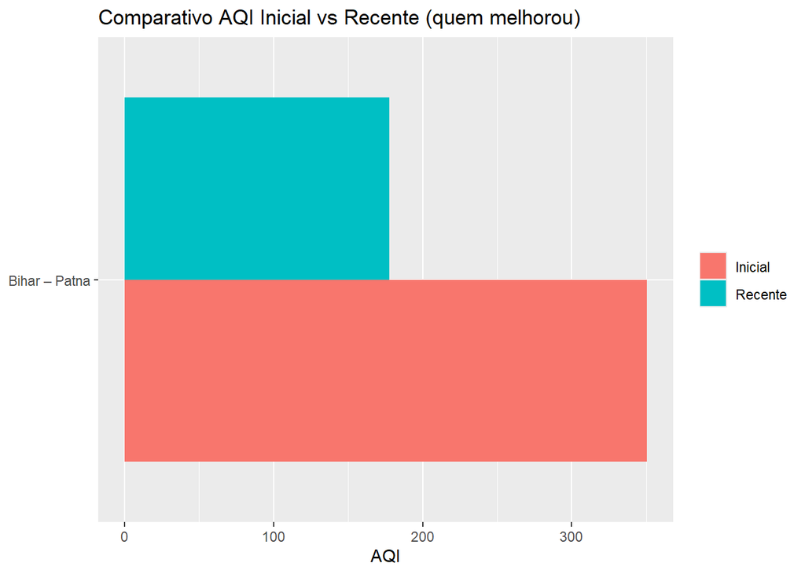

```r
library(tidyr)
library(ggplot2)

#### 1. Junta medias iniciais e recentes pelas chaves

comparativo <- med_iniciais %>%
  inner_join(med_recentes, by = c("state","city")) %>%

#### 2. Filtra quem melhorou

  filter(media_inicial > media_geral, media_recente < media_geral) %>%

#### 3. Prepara para pivot_longer

  rename(Inicial = media_inicial, Recente = media_recente) %>%
  select(state, city, Inicial, Recente)

#### 4. Empilha para fazer dodge bars

comparativo_long <- comparativo %>%
  pivot_longer(
    cols      = c(Inicial, Recente),
    names_to  = "Período",
    values_to = "AQI"
  ) %>%
  mutate(label = paste(state, city, sep=" – "))

#### 5. Plota

ggplot(comparativo_long, aes(x = reorder(label, AQI), y = AQI, fill = Período)) +
  geom_col(position="dodge") +
  coord_flip() +
  labs(
    title = "Comparativo AQI Inicial vs Recente (quem melhorou)",
    x     = NULL,
    y     = "AQI",
    fill  = NULL
  )
```

```r
### f) Tabela final de resposta

med_iniciais %>%
  inner_join(med_recentes, by=c("state","city")) %>%
  filter(media_inicial > media_geral, media_recente < media_geral) %>%
  arrange(desc(media_inicial)) %>%
  slice_head(n = 10) %>%
  mutate(
    Rank           = row_number(),
    `Média Inicial` = round(media_inicial, 1),
    `Média Recente` = round(media_recente,  1)
  ) %>%
  select(Rank, Estado=state, Cidade=city, `Média Inicial`, `Média Recente`) %>%
  knitr::kable(align=c("c","l","l","r","r"))
```

| Rank | Estado | Cidade | Média Inicial | Média Recente |
| --- | --- | --- | --- | --- |
| 1 | Bihar | Patna | 350.6 | 177.8 |

## 📝❓ Pergunta 3: Comportamento de PM10 vs PM2.5 em cada cidade

### a) Amostra dos dados brutos

```r
head(aqi_stations %>% select(pm2_5, pm10, state, city))
```

```
## # A tibble: 6 × 4
##   pm2_5  pm10 state          city
##   <dbl> <dbl> <chr>          <chr>
## 1  71.4  116. Andhra Pradesh Amaravati
## 2  81.4  124. Andhra Pradesh Amaravati
## 3  78.3  129. Andhra Pradesh Amaravati
## 4  88.8  135. Andhra Pradesh Amaravati
## 5  64.2  104. Andhra Pradesh Amaravati
## 6  72.5  115. Andhra Pradesh Amaravati
```

### b) Linhas “problemáticas” (menos de 2 pares completos)

```r
aqi_stations %>%
  group_by(state, city) %>%
  summarise(n_obs = sum(!is.na(pm2_5)&!is.na(pm10))) %>%
  filter(n_obs < 2)
```

```
## # A tibble: 1 × 3
## # Groups:   state [1]
##   state         city    n_obs
##   <chr>         <chr>   <int>
## 1 Uttar Pradesh Lucknow     0
```

### c) Tabela tratada – cálculo de correlação

```r
correlacoes2 <- aqi_stations %>%
  group_by(state, city) %>%
  summarise(
    n_obs = sum(!is.na(pm2_5)&!is.na(pm10)),
    cor_pm = ifelse(n_obs>1, cor(pm2_5, pm10, use="complete.obs"), NA_real_),
    .groups="drop"
  )
head(correlacoes2)
```

```
## # A tibble: 6 × 4
##   state          city          n_obs cor_pm
##   <chr>          <chr>         <int>  <dbl>
## 1 Andhra Pradesh Amaravati       892  0.923
## 2 Andhra Pradesh Visakhapatnam  1221  0.857
## 3 Assam          Guwahati        501  0.784
## 4 Bihar          Patna           723  0.655
## 5 Chandigarh     Chandigarh      289  0.935
## 6 Delhi          Delhi         31766  0.828
```

### d) Gráfico scatter (top 6 cidades)

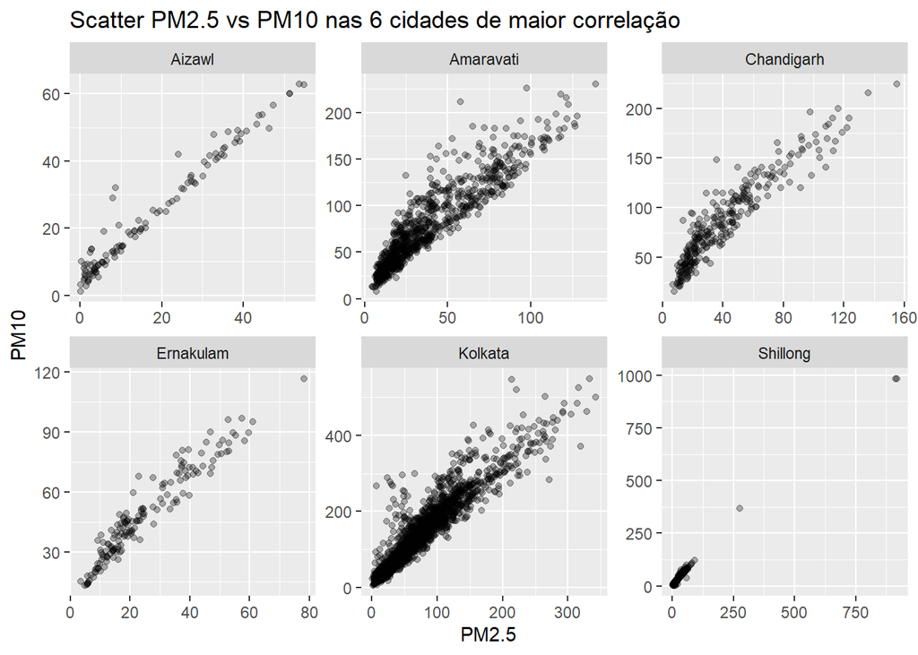

```r
top6 <- correlacoes2 %>%
  filter(!is.na(cor_pm)) %>%
  slice_max(cor_pm, n=6, with_ties=FALSE) %>%
  select(state, city)
aqi_stations %>%
  semi_join(top6, by=c("state","city")) %>%
  ggplot(aes(x=pm2_5, y=pm10)) +
    geom_point(alpha=0.3) +
    facet_wrap(~ city, scales="free") +
    labs(
      title="Scatter PM2.5 vs PM10 nas 6 cidades de maior correlação",
      x="PM2.5", y="PM10"
    )
```

### e) Tabela final de resposta

```r
correlacoes2 %>%
  filter(!is.na(cor_pm)) %>%
  slice_max(cor_pm, n=10, with_ties=FALSE) %>%
  mutate(
    Rank       = row_number(),
    Correlação = round(cor_pm, 2)
  ) %>%
  select(Rank, Estado=state, Cidade=city, Correlação) %>%
  knitr::kable(align=c("c","l","l","r"))
```

| Rank | Estado | Cidade | Correlação |
| --- | --- | --- | --- |
| 1 | Meghalaya | Shillong | 1.00 |
| 2 | Mizoram | Aizawl | 0.98 |
| 3 | Kerala | Ernakulam | 0.96 |
| 4 | West Bengal | Kolkata | 0.95 |
| 5 | Chandigarh | Chandigarh | 0.93 |
| 6 | Andhra Pradesh | Amaravati | 0.92 |
| 7 | Kerala | Thiruvananthapuram | 0.90 |
| 8 | Tamil Nadu | Coimbatore | 0.89 |
| 9 | Odisha | Brajrajnagar | 0.89 |
| 10 | Karnataka | Bengaluru | 0.88 |

# Conclusão

Neste relatório de análise da qualidade do ar na Índia, respondemos três perguntas-chave:

1. **Cidades e estados mais poluentes**  
   Top 10 Cidades/Estados Mais Poluentes (Pergunta 1)

| Rank | Estado | Cidade | Média AQI |
| --- | --- | --- | --- |
| 1 | Gujarat | Ahmedabad | 452.1 |
| 2 | Delhi | Delhi | 238.7 |
| 3 | Uttar Pradesh | Lucknow | 216.5 |
| 4 | Bihar | Patna | 215.6 |
| 5 | Haryana | Gurugram | 211.0 |
| 6 | Odisha | Talcher | 172.9 |
| 7 | Jharkhand | Jorapokhar | 159.3 |
| 8 | Odisha | Brajrajnagar | 150.3 |
| 9 | Assam | Guwahati | 140.1 |
| 10 | Rajasthan | Jaipur | 134.8 |

2. **Melhoria nos últimos dois anos**  
   Das cidades/estados que começaram acima da média geral de AQI, as que conseguiram reduzir suas médias anuais para abaixo da média geral nos dois últimos anos foram:

Cidades/estados que saíram de acima da média geral para abaixo nos últimos 2 anos

| Estado | Cidade | Média Inicial | Média Recente |
| --- | --- | --- | --- |
| Bihar | Patna | 350.6 | 177.8 |

3. **Similaridade PM2.5 vs PM10**  
   Calculamos o coeficiente de correlação entre PM2.5 e PM10 por cidade e verificamos que a maioria apresenta correlações muito altas (próximas de 1), indicando comportamento fortemente semelhante. Nas 6 cidades de maior correlação, o scatter plot mostra um alinhamento quase linear, confirmando essa relação.

Top 10 cidades com maior correlação entre PM2.5 e PM10

| Estado | Cidade | Correlação |
| --- | --- | --- |
| Meghalaya | Shillong | 1.00 |
| Mizoram | Aizawl | 0.98 |
| Kerala | Ernakulam | 0.96 |
| West Bengal | Kolkata | 0.95 |
| Chandigarh | Chandigarh | 0.93 |
| Andhra Pradesh | Amaravati | 0.92 |
| Kerala | Thiruvananthapuram | 0.90 |
| Tamil Nadu | Coimbatore | 0.89 |
| Odisha | Brajrajnagar | 0.89 |
| Karnataka | Bengaluru | 0.88 |

**Limitações e próximos passos:**  
- Em algumas cidades faltaram dados completos de PM2.5/PM10, o que excluiu esses casos da análise de correlação.  
- Poderíamos estender o estudo agregando por região ou avaliando sazonalidade mais fina (mensal/diária).  
- Uma análise de séries temporais (ARIMA, decomposição sazonal) ajudaria a entender tendências e picos de poluição.